# Dissimilarity time series analysis excluding species present in less than 1/3 of years

Zoë J. Kitchel

May 9, 2024

Script 4f for Kitchel et al. 2024 in prep taxonomic diversity manuscript.

```r
library(data.table)
library(vegan)
library(sf)
library(concaveman) #polygon around points
library(betapart) #allows us to partition beta diversity
library(geosphere)
library(ggpubr) #stat_regline_equation
library(nlme)
library(mgcv) #to make gam
library(cowplot)
library(lme4)
library(stringr)
```

Pull dissimilarity table

```r
#Pull Dissimilarity Means
distances_dissimilarities_allyears_onethirdyears_excluded <- readRDS(here::here("output", "dissimilarities", "distances_dissimilarities_allyears_onethirdyears_excluded.rds"))

#make survey and survey unit factors
distances_dissimilarities_allyears_onethirdyears_excluded[,survey:=factor(survey)][,survey_unit:=factor(survey_unit)]

#adjust years
distances_dissimilarities_allyears_onethirdyears_excluded[,year_adj := year-min(year)+1]

#add new variable for year in sequence per region
distances_dissimilarities_allyears_onethirdyears_excluded[,first_year := min(year),.(survey_unit)]
distances_dissimilarities_allyears_onethirdyears_excluded[,last_year := max(year),.(survey_unit)]

#distances_dissimilarities_allyears_onethirdyears_excluded[,year_in_seq := year-first_year+1]

distances_dissimilarities_allyears_onethirdyears_excluded[,years_sampled := last_year-first_year+1]
```

List of surveys

```r
#list of surveys
survey_unit.list <- levels(factor(distances_dissimilarities_allyears_onethirdyears_excluded$survey_unit))
```

Pull in palette and name helper

```r
source(here::here("analysis_code","color_links.R"))
```

##Make GAM (Generalized Additive Models)

Jaccard

```r
jaccard_total_gam <- gam(annual_dissimilarity_value ~ year + s(survey_unit, year, bs = "fs", m = 1),#random smooth
                            data = distances_dissimilarities_allyears_onethirdyears_excluded[dissimilarity_metric == "jaccard_dissimilarity_total"])
```

##Make LMERS

```r
#running with lme instead of lmer gave same results, but allowed for calculation of p-value

#Jaccard total with lme
jaccard_total_lme <- lme(annual_dissimilarity_value ~ year_adj, random = (~1 + year_adj|survey_unit),data = distances_dissimilarities_allyears_onethirdyears_excluded[dissimilarity_metric == "jaccard_dissimilarity_total"])

#Jaccard total with lmer
jaccard_total_lmer <- lmer(annual_dissimilarity_value ~ year_adj + (1 + year_adj|survey_unit),data = distances_dissimilarities_allyears_onethirdyears_excluded[dissimilarity_metric == "jaccard_dissimilarity_total"]) #FYI doesn't converge
summary(jaccard_total_lme)
```

```
Linear mixed-effects model fit by REML
  Data: distances_dissimilarities_allyears_onethirdyears_excluded[dissimilarity_metric ==      "jaccard_dissimilarity_total"]
```

|  | AIC | BIC | logLik |
| --- | --- | --- | --- |
|  | -307.4935 | -280.6225 | 159.7468 |

```
Random effects:
 Formula: ~1 + year_adj | survey_unit
 Structure: General positive-definite, Log-Cholesky parametrization
            StdDev      Corr
(Intercept) 0.247123600 (Intr)
year_adj    0.005868901 -0.881
Residual    0.173094440

Fixed effects:  annual_dissimilarity_value ~ year_adj
```

|  | Value | Std.Error | DF | t-value | p-value |
| --- | --- | --- | --- | --- | --- |
| (Intercept) | 0.8102567 | 0.05868760 | 618 | 13.806268 | 0.0000 |
| year_adj | 0.0007166 | 0.00140598 | 618 | 0.509678 | 0.6105 |

```
 Correlation:
         (Intr)
year_adj -0.929

Standardized Within-Group Residuals:
       Min         Q1        Med         Q3        Max
-4.7240885 -0.2163876  0.1748440  0.4763238  2.5422183

Number of Observations: 653
Number of Groups: 34
```

```r
anova(jaccard_total_lme)
```

|  | numDF | denDF | F-value | p-value |
| --- | --- | --- | --- | --- |
| (Intercept) | 1 | 618 | 1491.2682 | <.0001 |
| year_adj | 1 | 618 | 0.2598 | 0.6105 |

```r
#EXPORT JACCARD COEFFICIENTS
jaccard_total_coefs <- data.table(coef(jaccard_total_lme))
jaccard_total_coefs[,survey_unit := rownames(coef(jaccard_total_lme))][,Year := round(year_adj,5)][,Intercept := round(`(Intercept)`,2)]
#View(jaccard_total_coefs)

jaccard_total_coefs <- jaccard_total_coefs[color_link, on = "survey_unit"]

jaccard_total_coefs.exp_onethirdyears_excluded <- jaccard_total_coefs[,.(Survey_Name_Season, Intercept, Year)]

#export this table
fwrite(jaccard_total_coefs.exp_onethirdyears_excluded, file = here::here("output","jaccard_total_coefs.exp_onethirdyears_excluded.csv"))
```

##Linear Model

Also, build a simple linear model with an interaction (instead of random slope and intercept for survey) **THIS IS HOW WE CLASSIFY SURVEYS as of fall 2023 (update from before, where we classified surveys from LMER)** (Especially good because lmer didn’t converge)

Same, but for Jaccard

```r
jaccard_total_lm <- lm(annual_dissimilarity_value ~ year * survey_unit,data = distances_dissimilarities_allyears_onethirdyears_excluded[dissimilarity_metric == "jaccard_dissimilarity_total"])

jaccard_total_coefs <- data.table(summary(jaccard_total_lm)$coefficients)
  jaccard_total_coefs[,var := rownames(summary(jaccard_total_lm)$coefficients)]

  #limit to interactions only (check this if there are any model changes!) row 2 and rows 36:68
  jaccard_total_coefs.r_onethirdyears_excluded <- jaccard_total_coefs[c(2,36:68),]

  #adjust survey unit name by deleting beginning of string
  jaccard_total_coefs.r_onethirdyears_excluded[,survey_unit := substr(var, 17, str_length(var))][var == "year",survey_unit := "AI"]

  #calculate interaction coefficients
  AI_estimate <- jaccard_total_coefs.r_onethirdyears_excluded[1,Estimate]
  jaccard_total_coefs.r_onethirdyears_excluded[1,survey_unit_coefficient := AI_estimate]
  jaccard_total_coefs.r_onethirdyears_excluded[2:34,survey_unit_coefficient := (AI_estimate + Estimate)]

  #homogenizing vs differentiating
  jaccard_total_coefs.r_onethirdyears_excluded[,differentiating := ifelse((`Std. Error`< abs(survey_unit_coefficient) & survey_unit_coefficient > 0),1,0)][,homogenizing := ifelse((`Std. Error`< abs(survey_unit_coefficient) & survey_unit_coefficient < 0),1,0)]

  #lower and upper CI
    jaccard_total_coefs.r_onethirdyears_excluded[,lwr := survey_unit_coefficient-`Std. Error`][,upr:= survey_unit_coefficient+`Std. Error`]

    #save as output
    fwrite(jaccard_total_coefs.r_onethirdyears_excluded, here::here("output","jaccard_total_coefs.r_onethirdyears_excluded.csv"))

  jaccard_total_coefs_sum <- data.table(differentiating = sum(  jaccard_total_coefs.r_onethirdyears_excluded$differentiating), homogenizing = sum(  jaccard_total_coefs.r_onethirdyears_excluded$homogenizing))

  #hex by trend
  jaccard_total_coefs.r_onethirdyears_excluded[,trend_color_jaccard := ifelse(homogenizing == 1,"#FFC109", ifelse(differentiating == 1,"#D81C60","#1E88E5"))]

  #link to color link
  jaccard_total_coefs.r_onethirdyears_excluded <- color_link[jaccard_total_coefs.r_onethirdyears_excluded, on = "survey_unit"]

  color_link_trend_jaccard <- jaccard_total_coefs.r_onethirdyears_excluded[,.(survey_unit,Survey_Name_Season, hex,  trend_color_jaccard)]
```

##Get LMER models as predictions

```r
#new data for lmer
lmer_year <- seq(min(distances_dissimilarities_allyears_onethirdyears_excluded[,year]), max(distances_dissimilarities_allyears_onethirdyears_excluded[,year]), by = 0.1)

lmer_year_adj <- seq(min(distances_dissimilarities_allyears_onethirdyears_excluded[,year_adj]), max(distances_dissimilarities_allyears_onethirdyears_excluded[,year_adj]), by = 0.1)
```

```r
#predict average lmer
lmer_jaccard_total_predictions <- data.table(year = lmer_year, year_adj = lmer_year_adj)

#confidence intervals
jaccard_total_lmer_confint <- confint(jaccard_total_lmer)
```

```
Computing profile confidence intervals ...
Warning: non-monotonic profile for .sig02Warning: bad spline fit for .sig02: falling back to linear interpolation
```

```r
#populate data table of lmer predictions
lmer_jaccard_total_predictions[,jaccard_lmer_preds := fixef(jaccard_total_lmer)[[1]] + fixef(jaccard_total_lmer)[[2]] * year_adj][,jaccard_lmer_preds_lowerCI := jaccard_total_lmer_confint[5] + jaccard_total_lmer_confint[6] * year_adj][,jaccard_lmer_preds_upperCI := jaccard_total_lmer_confint[11] + jaccard_total_lmer_confint[12] * year_adj]
```

##Lollipop SE plot by linear trend experienced

Jaccard total dissimilarity

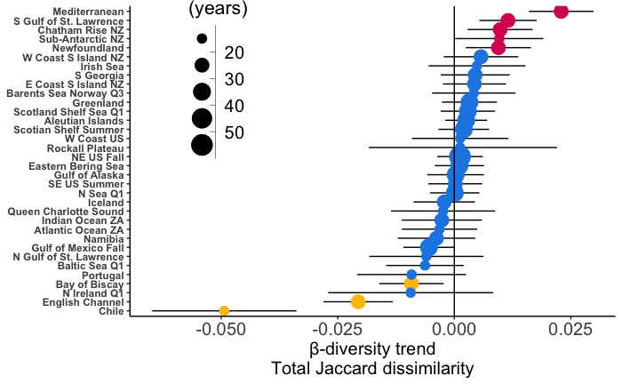

```r
jaccard_total_coefs.r_onethirdyears_excluded[,Directional_Change_sig := ifelse(differentiating > 0, "Differentiation",ifelse(homogenizing > 0 , "Homogenization", "No β-diversity trend"))]
years_sampled <- unique(distances_dissimilarities_allyears_onethirdyears_excluded[,.(survey_unit, years_sampled)])
jaccard_total_coefs.r_onethirdyears_excluded <- years_sampled[jaccard_total_coefs.r_onethirdyears_excluded, on = "survey_unit"]

(jaccard_total_Dissimilarity_Coef_errorbar_reduced_colorbytrend_LINEAR_MODEL_onethirdyears_excluded <- ggplot(data = jaccard_total_coefs.r_onethirdyears_excluded, aes(x = reorder(Survey_Name_Season, survey_unit_coefficient) , y = survey_unit_coefficient), label = Survey_Name_Season) +
    geom_errorbar(aes(ymin = lwr, ymax = upr), fill = "grey", width = 0) + #add confidence intervals
  geom_point(aes(size = years_sampled, color = Directional_Change_sig), stat = 'identity') +
  scale_color_manual(values = c("#D81C60","#FFC109","#1E88E5"), name = "β-diversity trend\nTotal Jaccard dissimilarity", guide="none") +
  scale_size_binned(range = c(1,8), name = "Survey period length\n(years)") +
  geom_hline(yintercept = 0) +
 # scale_y_continuous(breaks = seq(-0.0075, 0.0075, by = 0.0025), labels = c("-0.0075","","-0.0025","0", "0.0025", "",  "")) +
  xlab("Survey unit") +
  ylab("β-diversity trend\nTotal Jaccard dissimilarity") + #total jaccard dissimilarity trend
  coord_flip() +
  theme_classic() +
  theme(axis.text.y = element_text(face = "bold"), axis.title.y = element_blank(), axis.text.x = element_text(size = 15), axis.title.x = element_text(size = 15), legend.position = c(0.3,0.8), legend.direction = "vertical", legend.text = element_text(size = 15), legend.title = element_text(size = 16)))
ggsave(jaccard_total_Dissimilarity_Coef_errorbar_reduced_colorbytrend_LINEAR_MODEL_onethirdyears_excluded,
       path = here::here("figures"), filename = "jaccard_total_Dissimilarity_Coef_errorbar_reduced_colorbytrend_LINEAR_MODEL_onethirdyears_excluded.jpg", height = 7, width = 7)
```

#Figure to merge full dataset with two sensitivity analyses for supplement

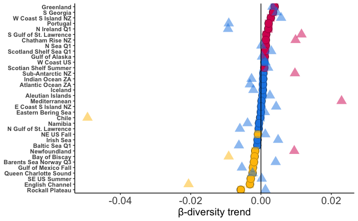

```r
#load true jaccard total coefs
jaccard_total_coefs.r <- fread(here::here("output","jaccard_total_coefs.r.csv"))
jaccard_total_coefs.r[,Directional_Change_sig_fulljaccard := ifelse(differentiating > 0, "Differentiation",ifelse(homogenizing > 0 , "Homogenization", "No β-diversity trend"))]
jaccard_total_coefs.r[,trend_color_jaccard_full := ifelse(homogenizing == 1,"#FFC109", ifelse(differentiating == 1,"#D81C60","#1E88E5"))]


#load 15perc exclude jaccard total coefs
jaccard_total_coefs.r_15perc_excluded <- fread(here::here("output","jaccard_total_coefs.r_15perc_excluded.csv"))
jaccard_total_coefs.r_15perc_excluded[,Directional_Change_sig_15perc_excluded_jaccard := ifelse(differentiating > 0, "Differentiation",ifelse(homogenizing > 0 , "Homogenization", "No β-diversity trend"))]
jaccard_total_coefs.r_15perc_excluded[,trend_color_jaccard_15percexluded := ifelse(homogenizing == 1,"#FFC109", ifelse(differentiating == 1,"#D81C60","#1E88E5"))]

#full dataset coefs
jaccard_total_coefs.r[,jaccard_coefficient := survey_unit_coefficient]
all_total_coefs <- jaccard_total_coefs.r[,.(survey_unit, jaccard_coefficient, Directional_Change_sig_fulljaccard, trend_color_jaccard_full)]

#15 percent exclude coefs
jaccard_total_coefs.r_15perc_excluded[,jaccard_coefficient_15percexclude := survey_unit_coefficient]
jaccard_total_coefs.r_15perc_excluded.r <- jaccard_total_coefs.r_15perc_excluded[,.(survey_unit, jaccard_coefficient_15percexclude, Directional_Change_sig_15perc_excluded_jaccard, trend_color_jaccard_15percexluded)]
all_total_coefs <- all_total_coefs[jaccard_total_coefs.r_15perc_excluded.r, on = "survey_unit"]

#one third years exclude (this script)
jaccard_total_coefs.r_onethirdyears_excluded[,onethirdyears_relative_coefficient := survey_unit_coefficient][,Directional_Change_onethirdyears := Directional_Change_sig][,trend_color_jaccard_onethirdyears_excluded := trend_color_jaccard]
jaccard_total_coefs.r_onethirdyears_excluded.r <- jaccard_total_coefs.r_onethirdyears_excluded[,.(survey_unit, Survey_Name_Season, onethirdyears_relative_coefficient, Directional_Change_onethirdyears, trend_color_jaccard_onethirdyears_excluded)]
all_total_coefs <- all_total_coefs[jaccard_total_coefs.r_onethirdyears_excluded.r, on = "survey_unit"]

#plot
(Dissimilarity_Coef_errorbar_reduced_colorbytrend_LINEAR_MODEL_spp_inclusion_sensitivity <- ggplot(data = all_total_coefs, aes(x = reorder(Survey_Name_Season, jaccard_coefficient)), label = Survey_Name_Season) +
  geom_point(aes(y = jaccard_coefficient, fill = Directional_Change_sig_fulljaccard), stat = 'identity',shape = 21, color = "black", size = 5) +
  geom_point(aes(y = jaccard_coefficient_15percexclude, color = Directional_Change_sig_15perc_excluded_jaccard), stat = 'identity', shape = 15, alpha = 0.5,size = 5) +
  geom_point(aes(y = onethirdyears_relative_coefficient, color = Directional_Change_onethirdyears), stat = 'identity', shape = 17, alpha = 0.5,size = 5) +
  scale_color_manual(values = c("#D81C60","#FFC109","#1E88E5"), name = "β-diversity trend", guide="none") +
  scale_fill_manual(values = c("#D81C60","#FFC109","#1E88E5"), name = "β-diversity trend", guide="none") +
  geom_hline(yintercept = 0) +
 # scale_y_continuous(breaks = seq(-0.0075, 0.0075, by = 0.0025), labels = c("-0.0075","","-0.0025","0", "0.0025", "",  "")) +
  xlab("Survey unit") +
  ylab("β-diversity trend") + #total jaccard dissimilarity trend
  coord_flip() +
  theme_classic() +
  theme(axis.text.y = element_text(face = "bold"), axis.title.y = element_blank(), axis.text.x = element_text(size = 15), axis.title.x = element_text(size = 15), legend.position = c(0.3,0.8), legend.direction = "vertical", legend.text = element_text(size = 15), legend.title = element_text(size = 16)))

ggsave(Dissimilarity_Coef_errorbar_reduced_colorbytrend_LINEAR_MODEL_spp_inclusion_sensitivity,
       path = here::here("figures"), filename = "Dissimilarity_Coef_errorbar_reduced_colorbytrend_LINEAR_MODEL_spp_inclusion_sensitivity.jpg", height = 7, width = 7)
```

##Wavy Line Plot for GAMs (Figure 2a)

Generate predicted values (this datatable will hold both jaccard and bray curtis total dissimilarities)

```r
#generate list again, as for some reason it doesn't stay in environment
survey_unit.list <- levels(factor(distances_dissimilarities_allyears_onethirdyears_excluded$survey_unit))

#generate new data to smooth lines (need year and season survey combinations)
year_survey_unit_expand.dt <- data.table(survey_unit = as.character(NULL), year = as.numeric(NULL), year_adj = as.numeric(NULL ))

for (i in 1:length(survey_unit.list)) {
  #generate year vectors
  survey_unit_years <- unique(distances_dissimilarities_allyears_onethirdyears_excluded[survey_unit == survey_unit.list[i],.(survey_unit, year, year_adj)])

  years <- seq(min(survey_unit_years[,year]), max(survey_unit_years[,year]), by = 0.1)

  year_adjust <- seq(min(survey_unit_years[,year_adj]), max(survey_unit_years[,year_adj]), by = 0.1)

  year_survey_unit_expand.dt_addition <- data.table(survey_unit = survey_unit.list[i], year = years, year_adj = year_adjust)

  year_survey_unit_expand.dt <- rbind(year_survey_unit_expand.dt, year_survey_unit_expand.dt_addition)
}


#add colors and names to full year and survey unit combination table
year_survey_unit_expand_jaccard.dt <- year_survey_unit_expand.dt[color_link_trend_jaccard, on = "survey_unit"]
```

Jaccard Get model as predictions

```r
#for plotting, get model as predictions
jaccard_total_gam_predictions <- predict(jaccard_total_gam, se.fit = TRUE, newdata = year_survey_unit_expand_jaccard.dt)

#merge into table
year_survey_unit_expand_jaccard.dt[,jaccard_glm_mod_fit := jaccard_total_gam_predictions$fit][,jaccard_glm_mod_fit_SE := jaccard_total_gam_predictions$se.fit]
```

##Color GAMs by trend (year vs dissimilarity) ###Jaccard dissimilarity

```r
#link distances dissimilarities with trend color hex
distances_dissimilarities_allyears_onethirdyears_excluded_jaccard <- distances_dissimilarities_allyears_onethirdyears_excluded[color_link_trend_jaccard, on = "survey_unit"]
distances_dissimilarities_allyears_onethirdyears_excluded_jaccard <- distances_dissimilarities_allyears_onethirdyears_excluded_jaccard[dissimilarity_metric == "jaccard_dissimilarity_total_abundance"]
#and again for jaccard
distances_dissimilarities_allyears_onethirdyears_excluded_jaccard <- distances_dissimilarities_allyears_onethirdyears_excluded[color_link_trend_jaccard, on = "survey_unit"]
distances_dissimilarities_allyears_onethirdyears_excluded_jaccard<- distances_dissimilarities_allyears_onethirdyears_excluded_jaccard[dissimilarity_metric == "jaccard_dissimilarity_total"]

#change survey_unit to factor
distances_dissimilarities_allyears_onethirdyears_excluded_jaccard[,survey_unit := factor(survey_unit)]
year_survey_unit_expand_jaccard.dt[,survey_unit := factor(survey_unit)]

#check that survey_unit in alpha order
sort(unique(distances_dissimilarities_allyears_onethirdyears_excluded_jaccard$survey_unit)) == levels(distances_dissimilarities_allyears_onethirdyears_excluded_jaccard$survey_unit)
```

```
 [1] TRUE TRUE TRUE TRUE TRUE TRUE TRUE TRUE TRUE TRUE TRUE TRUE TRUE TRUE TRUE TRUE TRUE TRUE TRUE TRUE TRUE TRUE TRUE TRUE TRUE TRUE TRUE TRUE TRUE TRUE TRUE TRUE TRUE TRUE
```

```r
sort(unique(year_survey_unit_expand_jaccard.dt$survey_unit)) == levels(year_survey_unit_expand_jaccard.dt$survey_unit)
```

```
 [1] TRUE TRUE TRUE TRUE TRUE TRUE TRUE TRUE TRUE TRUE TRUE TRUE TRUE TRUE TRUE TRUE TRUE TRUE TRUE TRUE TRUE TRUE TRUE TRUE TRUE TRUE TRUE TRUE TRUE TRUE TRUE TRUE TRUE TRUE
```

```r
#get list of colors in the right order
trend_colors_jaccard.dt <- unique(distances_dissimilarities_allyears_onethirdyears_excluded_jaccard[dissimilarity_metric == "jaccard_dissimilarity_total",.(survey_unit, Survey_Name_Season, trend_color_jaccard)])

#make sure it matches year_survey_unit_expand.dt
all(trend_colors_jaccard.dt == unique(year_survey_unit_expand_jaccard.dt[,.(survey_unit, Survey_Name_Season, trend_color_jaccard)]))
```

```
[1] TRUE
```

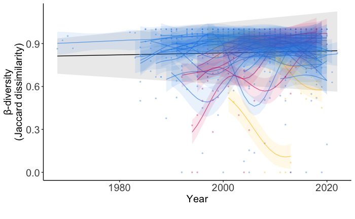

```r
setorder(trend_colors_jaccard.dt, survey_unit)


points_wavylines_jaccard_total_year_reduced_gam_colorbytrend_onethirdyears_excluded <- ggplot() +
  #full LMER predictions (black)
  geom_ribbon(data = lmer_jaccard_total_predictions, aes(x = year, ymin = jaccard_lmer_preds_lowerCI, ymax = jaccard_lmer_preds_upperCI), fill = "grey", alpha = 0.3) +
    geom_line(data = lmer_jaccard_total_predictions, aes(x = year, y = jaccard_lmer_preds), color = "black") +
  #points by trend
  geom_point(data = distances_dissimilarities_allyears_onethirdyears_excluded[dissimilarity_metric =="jaccard_dissimilarity_total"], cols = "year_adj",
             aes(x = year,
                 y = annual_dissimilarity_value,
                 fill = survey_unit), alpha = 0.4, size = 1, shape = 21, color = "white") +
  #squiggly lines by survey unit based GAM and colored by trend
    geom_line(data = year_survey_unit_expand_jaccard.dt, cols = "year_adj",
             aes(x = year,
                 y = jaccard_glm_mod_fit,
                 color = survey_unit), alpha = 0.6) +
  #confidence intervals for individual GAM
  geom_ribbon(data = year_survey_unit_expand_jaccard.dt, cols = "year_adj",
              aes(x = year, ymin=jaccard_glm_mod_fit-jaccard_glm_mod_fit_SE, ymax=jaccard_glm_mod_fit+jaccard_glm_mod_fit_SE, fill =  survey_unit), alpha=0.1) + #add standard error
  #set color by survey
    scale_color_manual(values = trend_colors_jaccard.dt$trend_color, name = "Survey Unit") +
  scale_fill_manual(values =trend_colors_jaccard.dt$trend_color, guide = "none") +
  theme_classic() +
  lims(x = c(min(distances_dissimilarities_allyears_onethirdyears_excluded[dissimilarity_metric == "jaccard_dissimilarity_total",year]),max(distances_dissimilarities_allyears_onethirdyears_excluded[dissimilarity_metric == "jaccard_dissimilarity_total",year]))
       ) +
  xlab("Year\n") +
ylab("β-diversity\n(Jaccard dissimilarity)") +
  theme(legend.position = "null", axis.text = element_text(size = 15), axis.title = element_text(size = 15))
points_wavylines_jaccard_total_year_reduced_gam_colorbytrend_onethirdyears_excluded

ggsave(points_wavylines_jaccard_total_year_reduced_gam_colorbytrend_onethirdyears_excluded, path = here::here("figures"), filename ="points_wavylines_jaccard_total_year_reduced_gam_colorbytrend_onethirdyears_excluded.jpg", height = 6, width = 11, unit = "in")
```

```r
#plot for legend
directional_change_legend_plot_colorbytrend <- jaccard_total_Dissimilarity_Coef_errorbar_reduced_colorbytrend_LINEAR_MODEL_onethirdyears_excluded +
  theme(legend.position = "right", legend.background = element_rect(fill= "transparent"),
         legend.text = element_text(size = 15), legend.title = element_text(size = 16)) +
  guides(colour = guide_legend(override.aes = list(size=6)), size = "none")
```

```r
######################################################
##################JACCARDTOTAL
jaccard_total_GAM_LM_merge_legend_colorbytrend_onethirdyears_excluded <- ggdraw(xlim = c(0, 40.5), ylim = c(0, 21)) +
    draw_plot(points_wavylines_jaccard_total_year_reduced_gam_colorbytrend_onethirdyears_excluded + theme(axis.text = element_text(size = 14)),
                                         x = 1, y = 1, width = 20, height = 20) +
    draw_plot(jaccard_total_Dissimilarity_Coef_errorbar_reduced_colorbytrend_LINEAR_MODEL_onethirdyears_excluded +
        theme(legend.key.size = unit(0.5, 'cm'), #change legend key size
              axis.text = element_text(size = 8)), #change legend text font size),
                                         x = 20, y = 1, width = 19, height = 20) +
    draw_plot(get_legend(directional_change_legend_plot_colorbytrend +
      theme(legend.key.size = unit(0.5, 'cm'), #change legend key size
        legend.title = element_text(size=16), #change legend title font size
        legend.text = element_text(size=15))), #change legend text font size)
                                x = 27, y = 8, width = 3, height = 2) +
  geom_text(aes(x = 2, y = 20.7), label = ("a."), size =8, fontface = "bold") +
  geom_text(aes(x =20, y = 20.7), label = ("b."), size =8, fontface = "bold")
```

#THIS PORTION DOES NOT RUN BELOW BECAUSE CHILE DOES NOT HAVE ENOUGH DATA AFTER THIS SENSITIVITY ANALYSIS

###Is each survey better described by LM or by GAM? ####Also, compile predicted values from GAM ####Jaccard first

```r
#list of surveys
survey_unit.list_jaccard <- levels(factor(distances_dissimilarities_allyears_onethirdyears_excluded_jaccard$survey_unit))

# Function to compare GAM and linear model fits
compare_models <- function(subset_data) {
  # Fit GAM model with "fs" basis and single smooth term
  gam_model <- gam(annual_dissimilarity_value ~ s(year, bs = "fs", m = 1), data = subset_data)

  # Fit linear model
  lm_model <- lm(annual_dissimilarity_value ~ year, data = subset_data)

  # Calculate AICc values
  aicc_gam <- AICc(gam_model)
  aicc_lm <- AICc(lm_model)

  #Calculate p-values
  gam_pvalue <- summary(gam_model)$s.table[1,4]
  lm_pvalue <- summary(lm_model)$coefficients[2,4]

  comparison <- ifelse((abs(aicc_gam-aicc_lm) < 2 | (aicc_gam == aicc_lm)),"Same",
                       ifelse(((abs(aicc_gam-aicc_lm) > 2 & (aicc_gam < aicc_lm))),"GAM",
                              ifelse(((abs(aicc_gam-aicc_lm) > 2 & (aicc_gam > aicc_lm))), "Linear",NA)))

   return(data.table(Survey = unique(subset_data$Survey_Name_Season)[1],
                     survey_unit = unique(subset_data$survey_unit),
                    comparison = comparison,
                    aicc_gam = aicc_gam,
                    gam_p = gam_pvalue,
                    aicc_lm = aicc_lm,
                    lm_p = lm_pvalue))
}


############## Compare models for each survey name and bind the results
GAM_LM_model_comparisons_jaccard_total <- data.table()

for (i in 1:length(survey_unit.list_jaccard)) {
  GAM_LM_model_comparisons_jaccard_total_single <- compare_models(distances_dissimilarities_allyears_onethirdyears_excluded_jaccard[survey_unit == survey_unit.list_jaccard[i],])
  GAM_LM_model_comparisons_jaccard_total <- rbind(GAM_LM_model_comparisons_jaccard_total, GAM_LM_model_comparisons_jaccard_total_single)
}
```

```
Error in smooth.construct.tp.smooth.spec(object, data, knots) :
  A term has fewer unique covariate combinations than specified maximum degrees of freedom
```

###Model Comparison plots

Plot each jaccard total independently

Note that this is for independent linear models and independent generalized additive models, NOT models built for all surveys at once

```r
#plot each independently for supplement
#all survey names =
all_survey_names <- color_link_trend_jaccard$survey_unit

#set order of levels of Survey Name Season by survey unit
distances_dissimilarities_allyears_onethirdyears_excluded_jaccard[,Survey_Name_Season := factor(Survey_Name_Season, levels = trend_colors_jaccard.dt$Survey_Name_Season, ordered = T)]

#change year to integer
distances_dissimilarities_allyears_onethirdyears_excluded_jaccard[,year:=as.integer(year)]

#split into 2 and use facet
#first 17
points_wavylines_jaccard_total_year_reduced_gam_colorbytrend_onethirdyears_excluded_individual_facet_1_20 <- ggplot() +
  geom_point(data = distances_dissimilarities_allyears_onethirdyears_excluded_jaccard[survey_unit  %in% all_survey_names[c(1:20)]],
             aes(x = as.integer(year),
                 y = annual_dissimilarity_value), alpha = 0.3) +

    geom_smooth(data = distances_dissimilarities_allyears_onethirdyears_excluded_jaccard[survey_unit  %in% all_survey_names[c(1:20)]],
             aes(x = as.integer(year),
                 y = annual_dissimilarity_value,
                 color = survey_unit,
                 fill = survey_unit), method = "lm", linewidth = 0.5) +
  geom_smooth(data = distances_dissimilarities_allyears_onethirdyears_excluded_jaccard[survey_unit %in% all_survey_names[c(1:20)]],
              aes(x = as.integer(year),
                  y = annual_dissimilarity_value), method = "gam", linewidth = 0.5, formula = y ~ s(x, bs = "fs", m = 1), color = "black") +
    scale_color_manual(values =    color_link_trend_jaccard$trend_color[1:20], name = "Survey Unit") +
    scale_fill_manual(values =    color_link_trend_jaccard$trend_color[1:20], name = "Survey Unit") +
  scale_x_continuous(breaks = ~ axisTicks(., log = FALSE)) +
  theme_classic() +
  theme(axis.text.x = element_text(size = 7)) +
  xlab("Year") +
ylab("β-diversity\n(Jaccard dissimilarity)") +
  facet_wrap(~Survey_Name_Season, ncol = 4, scales = "free") +
  theme(axis.text = element_text(size = 8), axis.title = element_text(size = 12), legend.position = "null")

ggsave(points_wavylines_jaccard_total_year_reduced_gam_colorbytrend_onethirdyears_excluded_individual_facet_1_20, path =  here::here("figures"), filename = "points_wavylines_jaccard_total_year_reduced_gam_colorbytrend_onethirdyears_excluded_individual_facet_1_20.png", height = 12, width = 9.5)

#second portion
points_wavylines_jaccard_total_year_reduced_gam_colorbytrend_onethirdyears_excluded_individual_facet_21_34 <- ggplot() +
  geom_point(data = distances_dissimilarities_allyears_onethirdyears_excluded_jaccard[survey_unit  %in% all_survey_names[c(21:34)]],
             aes(x = as.integer(year),
                 y = annual_dissimilarity_value), alpha = 0.3) +

    geom_smooth(data = distances_dissimilarities_allyears_onethirdyears_excluded_jaccard[survey_unit  %in% all_survey_names[c(21:34)]],
             aes(x = as.integer(year),
                 y = annual_dissimilarity_value,
                 color = survey_unit,
                 fill = survey_unit), method = "lm", linewidth = 0.5) +
  geom_smooth(data = distances_dissimilarities_allyears_onethirdyears_excluded_jaccard[survey_unit %in% all_survey_names[c(21:34)]],
              aes(x = as.integer(year),
                  y = annual_dissimilarity_value), method = "gam", linewidth = 0.5, formula = y ~ s(x, bs = "fs", m = 1), color = "black") +
    scale_color_manual(values =    color_link_trend_jaccard$trend_color[21:34], name = "Survey Unit") +
    scale_fill_manual(values =    color_link_trend_jaccard$trend_color[21:34], name = "Survey Unit") +
  scale_x_continuous(breaks = ~ axisTicks(., log = FALSE)) +
  theme_classic() +
  theme(axis.text.x = element_text(size = 7)) +
  xlab("Year") +
ylab("β-diversity\n(Jaccard dissimilarity)") +
  facet_wrap(~Survey_Name_Season, ncol = 4, scales = "free") +
  theme(axis.text = element_text(size = 8), axis.title = element_text(size = 12), legend.position = "null")

ggsave(points_wavylines_jaccard_total_year_reduced_gam_colorbytrend_onethirdyears_excluded_individual_facet_21_34, path =  here::here("figures"), filename = "points_wavylines_jaccard_total_year_reduced_gam_colorbytrend_onethirdyears_excluded_individual_facet_21_34.png", height = 10, width = 9.5)
```